# Stroop Notebook

# Stroop PRE DATA ANALYSIS

## Data Prep

Getting the Data ready for analysis Defaults: R uses dummy coding as it’s default. In this sample, the control group and the congruent condition will be the dummy variables in the analysis. So all Estimates are relative to these dummy variables

### Load Requisite R Packages

note: some of these may not actually be used. Step 1) load the necessary libraries

```r
library(ggplot2)
library(lme4)
library(languageR)
library(lmerTest) #give p-values from mixed models
library(influence.ME)
library(plyr) # magic
library(scales) #for making percents on the y-axis of graphs
```

### Read in the dataset (in current directory)

```r
Stroop_data = read.table("Stroop_R_format.csv", header = TRUE, sep = ",")
```

### Omit missing data (e.g. from practice trials)

```r
Stroop_data = na.omit(Stroop_data)
head(Stroop_data, n = 20)
```

```
##    subject session        group    stimtype ACC   RT
## 19       5       1 Experimental Incongruent   1  988
## 20       5       1 Experimental   Congruent   1 1008
## 21       5       1 Experimental   Congruent   1  963
## 22       5       1 Experimental Incongruent   1  680
## 23       5       1 Experimental     Neutral   1  680
## 24       5       1 Experimental Incongruent   1 1159
## 25       5       1 Experimental     Neutral   1  772
## 26       5       1 Experimental     Neutral   1  801
## 27       5       1 Experimental Incongruent   1  844
## 28       5       1 Experimental   Congruent   1  662
## 29       5       1 Experimental Incongruent   1 1143
## 30       5       1 Experimental     Neutral   1  692
## 31       5       1 Experimental   Congruent   1  580
## 32       5       1 Experimental   Congruent   1  985
## 33       5       1 Experimental   Congruent   1 1292
## 34       5       1 Experimental   Congruent   1  948
## 35       5       1 Experimental Incongruent   1  777
## 36       5       1 Experimental     Neutral   1  774
## 37       5       1 Experimental     Neutral   1  946
## 38       5       1 Experimental     Neutral   1  712
```

### Omit the Undefined group from the data and specify group as a factor

```r
Stroop_data <- subset(Stroop_data,group=="Control" | group=="Experimental")
Stroop_data$group <- factor(Stroop_data$group)
summary(Stroop_data)
```

```
##     subject         session               group              stimtype
##  Min.   :  5.0   Min.   :1.000   Control     :27216   Congruent  :17136
##  1st Qu.: 45.0   1st Qu.:1.000   Experimental:24192   Incongruent:17136
##  Median : 98.0   Median :1.000                        Neutral    :17136
##  Mean   :104.4   Mean   :1.471                        practice   :    0
##  3rd Qu.:166.0   3rd Qu.:2.000
##  Max.   :209.0   Max.   :2.000
##       ACC               RT
##  Min.   :0.0000   Min.   :   0.0
##  1st Qu.:1.0000   1st Qu.: 724.0
##  Median :1.0000   Median : 876.0
##  Mean   :0.9633   Mean   : 906.1
##  3rd Qu.:1.0000   3rd Qu.:1064.2
##  Max.   :1.0000   Max.   :1897.0
```

```r
contrasts(Stroop_data$group)
```

```
##              Experimental
## Control                 0
## Experimental            1
```

### Omit the Practice stimtype and specify stimtype as a factor

```r
Stroop_data <- subset(Stroop_data,stimtype=="Congruent" | stimtype=="Incongruent" | stimtype=="Neutral")
Stroop_data$stimtype <- factor(Stroop_data$stimtype)
summary(Stroop_data)
```

```
##     subject         session               group              stimtype
##  Min.   :  5.0   Min.   :1.000   Control     :27216   Congruent  :17136
##  1st Qu.: 45.0   1st Qu.:1.000   Experimental:24192   Incongruent:17136
##  Median : 98.0   Median :1.000                        Neutral    :17136
##  Mean   :104.4   Mean   :1.471
##  3rd Qu.:166.0   3rd Qu.:2.000
##  Max.   :209.0   Max.   :2.000
##       ACC               RT
##  Min.   :0.0000   Min.   :   0.0
##  1st Qu.:1.0000   1st Qu.: 724.0
##  Median :1.0000   Median : 876.0
##  Mean   :0.9633   Mean   : 906.1
##  3rd Qu.:1.0000   3rd Qu.:1064.2
##  Max.   :1.0000   Max.   :1897.0
```

```r
contrasts(Stroop_data$stimtype)
```

```
##             Incongruent Neutral
## Congruent             0       0
## Incongruent           1       0
## Neutral               0       1
```

### Isolate the session to the first session

```r
Stroop_data_pre <- subset(Stroop_data, session==1)
Stroop_data_pre$session <- factor(Stroop_data_pre$session)
summary(Stroop_data_pre)
```

```
##     subject      session            group              stimtype
##  Min.   :  5.0   1:27216   Control     :14688   Congruent  :9072
##  1st Qu.: 45.0             Experimental:12528   Incongruent:9072
##  Median : 98.0                                  Neutral    :9072
##  Mean   :105.4
##  3rd Qu.:172.0
##  Max.   :209.0
##       ACC               RT
##  Min.   :0.0000   Min.   :   0.0
##  1st Qu.:1.0000   1st Qu.: 755.0
##  Median :1.0000   Median : 908.0
##  Mean   :0.9636   Mean   : 936.8
##  3rd Qu.:1.0000   3rd Qu.:1100.0
##  Max.   :1.0000   Max.   :1897.0
```

### specify subject as a factor

```r
Stroop_data_pre$subject <- as.factor(Stroop_data_pre$subject)

summary(Stroop_data_pre)
```

```
##     subject      session            group              stimtype
##  5      :  432   1:27216   Control     :14688   Congruent  :9072
##  6      :  432             Experimental:12528   Incongruent:9072
##  7      :  432                                  Neutral    :9072
##  8      :  432
##  9      :  432
##  10     :  432
##  (Other):24624
##       ACC               RT
##  Min.   :0.0000   Min.   :   0.0
##  1st Qu.:1.0000   1st Qu.: 755.0
##  Median :1.0000   Median : 908.0
##  Mean   :0.9636   Mean   : 936.8
##  3rd Qu.:1.0000   3rd Qu.:1100.0
##  Max.   :1.0000   Max.   :1897.0
##
```

## Stroop Accuracy Analysis

### Graph Accuracy Data

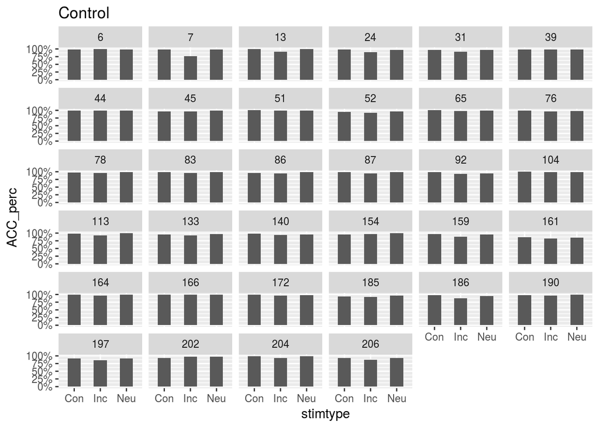

```r
#Control Group Data
Stroop_data_pre_control <- subset(Stroop_data_pre, group=="Control")
#change binary data to a percent
Stroop_data_pre_control_percent <- ddply(Stroop_data_pre_control, .(stimtype, subject), summarize, ACC_perc = mean(ACC))

#Experimental Group Data
Stroop_data_pre_experimental <- subset(Stroop_data_pre, group=="Experimental")
#change binary data to a percent
Stroop_data_pre_experimental_percent <- ddply(Stroop_data_pre_experimental, .(stimtype, subject), summarize, ACC_perc = mean(ACC))

ggplot(data = Stroop_data_pre_control_percent, aes( x = stimtype, y = ACC_perc)) + geom_bar(stat = "identity", width = 0.5) + facet_wrap(~subject) + scale_y_continuous(labels=percent) + scale_x_discrete(labels=c("Con","Inc","Neu")) + ggtitle("Control")
```

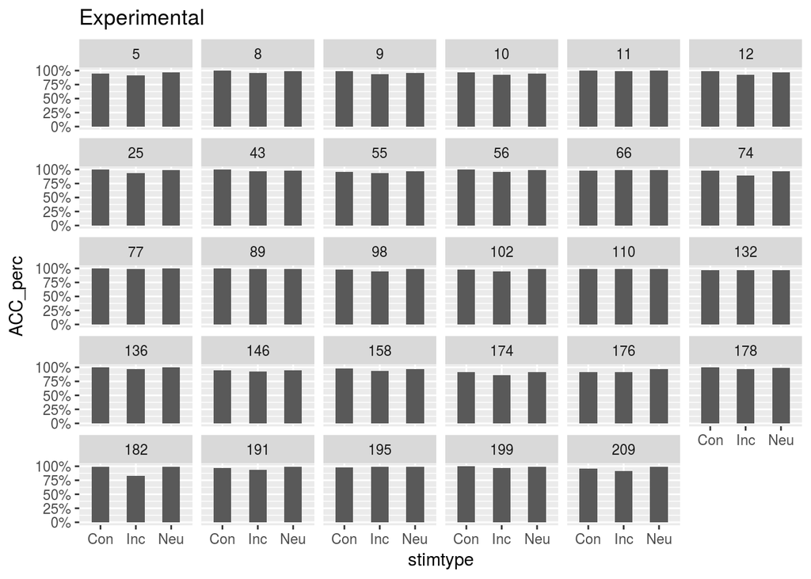

```r
ggplot(data = Stroop_data_pre_experimental_percent, aes( x = stimtype, y = ACC_perc)) + geom_bar(stat = "identity", width = 0.5) + facet_wrap(~subject) + scale_y_continuous(labels=percent) +  scale_x_discrete(labels=c("Con","Inc","Neu")) + ggtitle("Experimental")
```

**Conclusion**: Subjects have high accuracy accross the board, with some dips for the incongruent condition.

### Model Accuracy (Logit)

```r
Stroop_ACC_model<-glmer(ACC ~ group*stimtype + (1|subject), family=binomial, data=Stroop_data_pre, verbose=TRUE)
```

[output not shown]

```r
summary(Stroop_ACC_model)
```

```
## Generalized linear mixed model fit by maximum likelihood (Laplace
##   Approximation) [glmerMod]
##  Family: binomial  ( logit )
## Formula: ACC ~ group * stimtype + (1 | subject)
##    Data: Stroop_data_pre
##
##      AIC      BIC   logLik deviance df.resid
##   7967.9   8025.3  -3976.9   7953.9    27209
##
## Scaled residuals:
##      Min       1Q   Median       3Q      Max
## -13.5761   0.1151   0.1594   0.2060   0.5425
##
## Random effects:
##  Groups  Name        Variance Std.Dev.
##  subject (Intercept) 0.5654   0.7519
## Number of obs: 27216, groups:  subject, 63
##
## Fixed effects:
##                                       Estimate Std. Error z value Pr(>|z|)
## (Intercept)                            3.83264    0.15891  24.119   <2e-16
## groupExperimental                      0.20437    0.23778   0.860    0.390
## stimtypeIncongruent                   -0.92398    0.10528  -8.777   <2e-16
## stimtypeNeutral                        0.06429    0.12551   0.512    0.608
## groupExperimental:stimtypeIncongruent -0.06613    0.16300  -0.406    0.685
## groupExperimental:stimtypeNeutral     -0.01839    0.19532  -0.094    0.925
##
## (Intercept)                           ***
## groupExperimental
## stimtypeIncongruent                   ***
## stimtypeNeutral
## groupExperimental:stimtypeIncongruent
## groupExperimental:stimtypeNeutral
## ---
## Signif. codes:  0 '***' 0.001 '**' 0.01 '*' 0.05 '.' 0.1 ' ' 1
##
## Correlation of Fixed Effects:
##             (Intr) grpExp stmtyI stmtyN grpE:I
## grpExprmntl -0.662
## stmtypIncng -0.461  0.307
## stimtypNtrl -0.383  0.255  0.578
## grpExprmn:I  0.297 -0.483 -0.645 -0.373
## grpExprmn:N  0.246 -0.400 -0.371 -0.642  0.584
```

**Conclusion**: no group differences (as expected). Participant’s were significantly less accurate in the Incongruent condition (as expected)

## Stroop Reaction Time Analysis

### Format RT data

(subset for RTs when they are accurate, greater than 200ms, and less than 2000 ms) See how many observations are lost when we subset the data

```r
#all observations
print("All Data")
```

```
## [1] "All Data"
```

```r
All_data <- length(Stroop_data_pre$RT)
summary(Stroop_data_pre)
```

```
##     subject      session            group              stimtype
##  5      :  432   1:27216   Control     :14688   Congruent  :9072
##  6      :  432             Experimental:12528   Incongruent:9072
##  7      :  432                                  Neutral    :9072
##  8      :  432
##  9      :  432
##  10     :  432
##  (Other):24624
##       ACC               RT
##  Min.   :0.0000   Min.   :   0.0
##  1st Qu.:1.0000   1st Qu.: 755.0
##  Median :1.0000   Median : 908.0
##  Mean   :0.9636   Mean   : 936.8
##  3rd Qu.:1.0000   3rd Qu.:1100.0
##  Max.   :1.0000   Max.   :1897.0
##
```

```r
#remove innacurate responses
print("Removed innacurate trials (from all data dataframe)")
```

```
## [1] "Removed innacurate trials (from all data dataframe)"
```

```r
Stroop_data_pre_RT <- subset(Stroop_data_pre, ACC==1)
All_acc_data <- length(Stroop_data_pre_RT$RT)
summary(Stroop_data_pre_RT)
```

```
##     subject      session            group              stimtype
##  11     :  431   1:26224   Control     :14111   Congruent  :8846
##  166    :  431             Experimental:12113   Incongruent:8520
##  51     :  430                                  Neutral    :8858
##  77     :  430
##  89     :  429
##  104    :  429
##  (Other):23644
##       ACC          RT
##  Min.   :1   Min.   :  25.0
##  1st Qu.:1   1st Qu.: 762.0
##  Median :1   Median : 911.0
##  Mean   :1   Mean   : 949.2
##  3rd Qu.:1   3rd Qu.:1100.0
##  Max.   :1   Max.   :1897.0
##
```

```r
#remove short and long RTs
print("Removed slow and fast RTs")
```

```
## [1] "Removed slow and fast RTs"
```

```r
Stroop_data_pre_RT <- subset(Stroop_data_pre_RT, RT>200 & RT<2000)
filtered_data <- length(Stroop_data_pre_RT$RT)
summary(Stroop_data_pre_RT)
```

```
##     subject      session            group              stimtype
##  11     :  431   1:26218   Control     :14107   Congruent  :8843
##  166    :  431             Experimental:12111   Incongruent:8518
##  51     :  430                                  Neutral    :8857
##  77     :  430
##  89     :  429
##  104    :  429
##  (Other):23638
##       ACC          RT
##  Min.   :1   Min.   : 252.0
##  1st Qu.:1   1st Qu.: 762.0
##  Median :1   Median : 911.0
##  Mean   :1   Mean   : 949.4
##  3rd Qu.:1   3rd Qu.:1100.0
##  Max.   :1   Max.   :1897.0
##
```

```r
print("Percentage of Data Removed")
```

```
## [1] "Percentage of Data Removed"
```

```r
perc_data_rm <- (1 - (filtered_data/All_acc_data) ) * 100
perc_data_rm
```

```
## [1] 0.0228798
```

**Conclusion**: barely any data removed from RT filtering. Good to go.

### Graph RT data

Note: just doing it by stimtype since subject data appears to be in good ranges

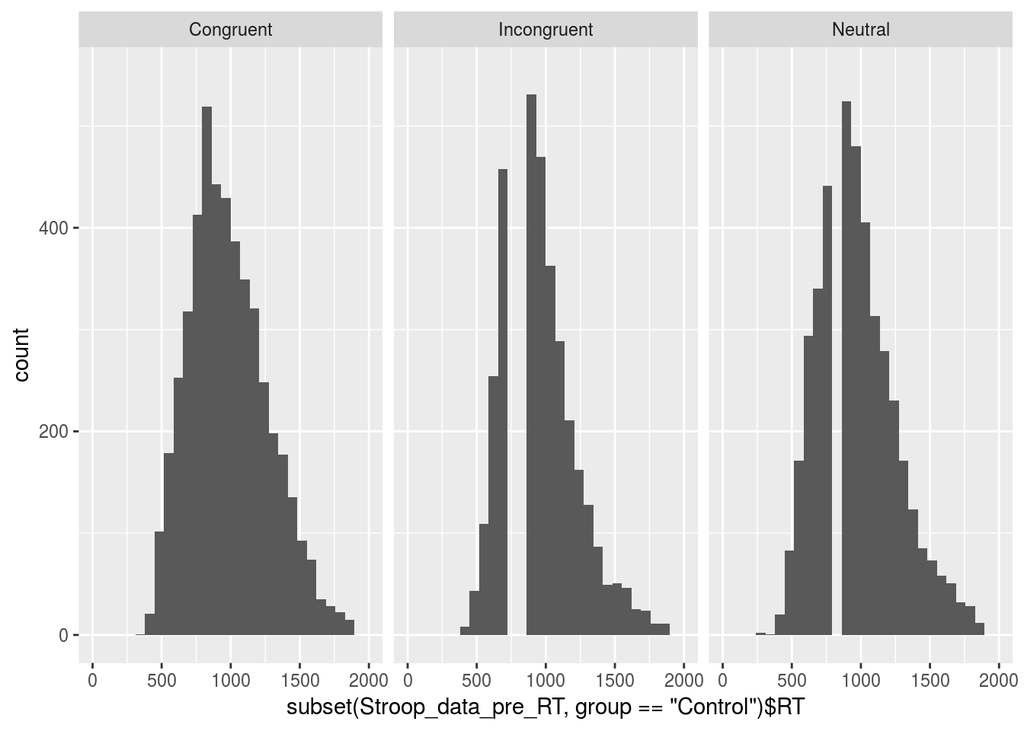

```r
#hist(subset(Stroop_data_pre_RT, group=="Control")$RT,ylim=c(0,1600))
#hist(subset(Stroop_data_pre_RT, group=="Experimental")$RT,ylim=c(0,1600))
ggplot(data = subset(Stroop_data_pre_RT, group=="Control"), aes(subset(Stroop_data_pre_RT, group=="Control")$RT)) + geom_histogram() + facet_wrap(~subset(Stroop_data_pre_RT, group=="Control")$stimtype) + scale_y_continuous(limits = c(0,550)) + scale_x_continuous(limits = c(0,2000))
```

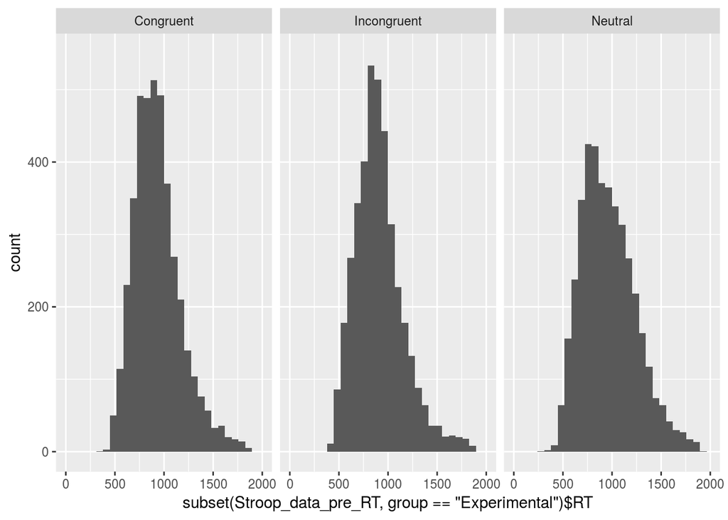

```r
ggplot(data = subset(Stroop_data_pre_RT, group=="Experimental"), aes(subset(Stroop_data_pre_RT, group=="Experimental")$RT)) + geom_histogram() + facet_wrap(~subset(Stroop_data_pre_RT, group=="Experimental")$stimtype) + scale_y_continuous(limits = c(0,550)) + scale_x_continuous(limits = c(0,2000))
```

**Conclusion**: data show a bit of skew, will transform to see if they look better

### Log Transform RT data

```r
Stroop_data_pre_RT$log_RT <- log(1/Stroop_data_pre_RT$RT)
```

### graph logged RT data

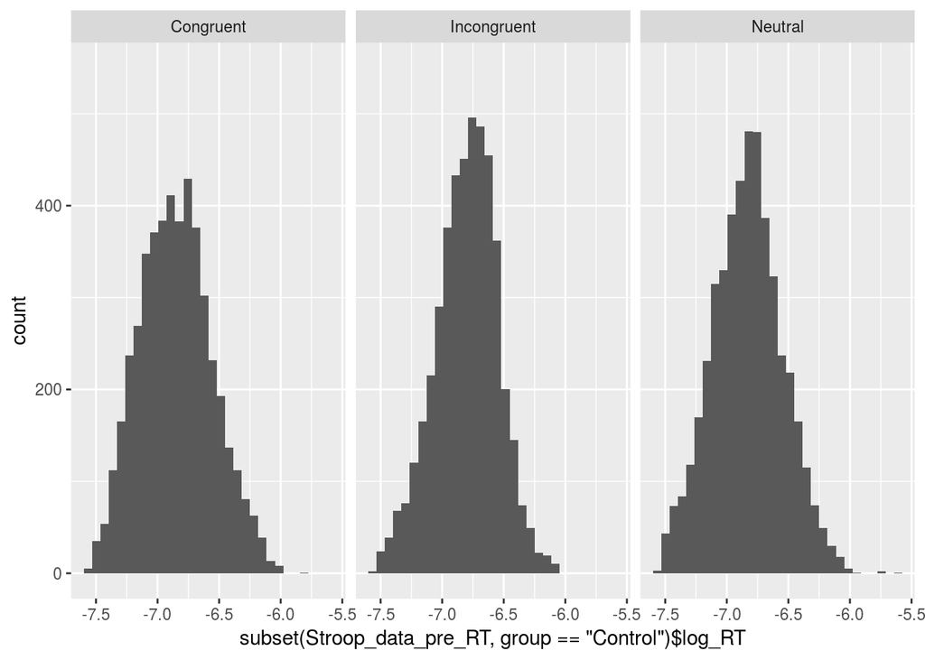

```r
#hist(subset(Stroop_data_pre_RT, group=="Control")$RT,ylim=c(0,1600))
#hist(subset(Stroop_data_pre_RT, group=="Experimental")$RT,ylim=c(0,1600))
ggplot(data = subset(Stroop_data_pre_RT, group=="Control"), aes(subset(Stroop_data_pre_RT, group=="Control")$log_RT)) + geom_histogram() + facet_wrap(~subset(Stroop_data_pre_RT, group=="Control")$stimtype) + scale_y_continuous(limits = c(0,550))
```

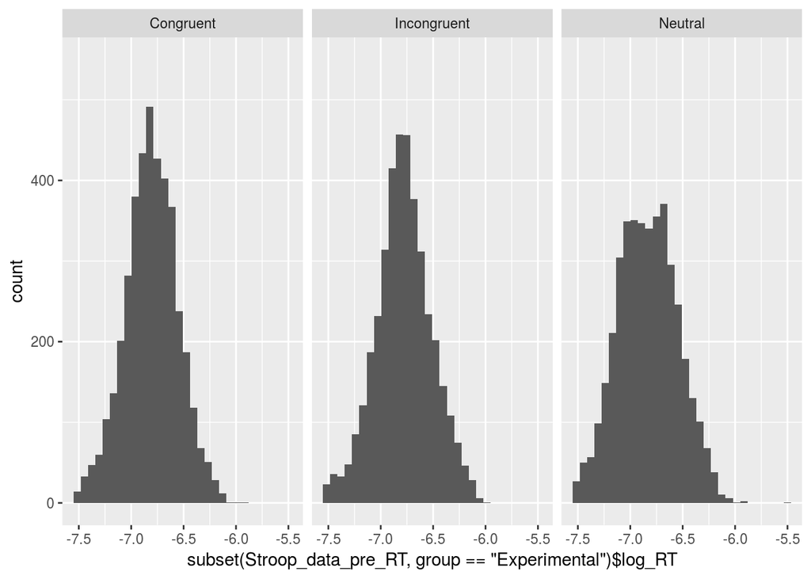

```r
ggplot(data = subset(Stroop_data_pre_RT, group=="Experimental"), aes(subset(Stroop_data_pre_RT, group=="Experimental")$log_RT)) + geom_histogram() + facet_wrap(~subset(Stroop_data_pre_RT, group=="Experimental")$stimtype) + scale_y_continuous(limits = c(0,550))
```

**Conclusion**: This appears to introduce more outliers, I’m going to stick with the untransformed data for analysis

### Model RT by group and stimtype

```r
Stroop_RT_model <- lmer(RT ~ group*stimtype + (1|subject), data = Stroop_data_pre_RT)
summary(Stroop_RT_model)
```

[output not shown]

**Conclusions**: No main group effect or interactions (as expected), The incongruent and neutral trials are slower relative to congruent trials (as expected)

### Model log RT by group and stimtype

```r
Stroop_log_RT_model <- lmer(log_RT ~ group*stimtype + (1|subject), data = Stroop_data_pre_RT)
summary(Stroop_log_RT_model)
```

```
## Linear mixed model fit by REML t-tests use Satterthwaite approximations
##   to degrees of freedom [lmerMod]
## Formula: log_RT ~ group * stimtype + (1 | subject)
##    Data: Stroop_data_pre_RT
##
## REML criterion at convergence: -259.6
##
## Scaled residuals:
##     Min      1Q  Median      3Q     Max
## -3.7681 -0.6113  0.0385  0.6159  5.7214
##
## Random effects:
##  Groups   Name        Variance Std.Dev.
##  subject  (Intercept) 0.01434  0.1197
##  Residual             0.05724  0.2392
## Number of obs: 26218, groups:  subject, 63
##
## Fixed effects:
##                                         Estimate Std. Error         df
## (Intercept)                           -6.769e+00  2.083e-02  6.300e+01
## groupExperimental                      1.842e-02  3.070e-02  6.300e+01
## stimtypeIncongruent                   -1.490e-01  4.954e-03  2.615e+04
## stimtypeNeutral                       -3.784e-02  4.902e-03  2.615e+04
## groupExperimental:stimtypeIncongruent  7.471e-03  7.286e-03  2.615e+04
## groupExperimental:stimtypeNeutral      3.995e-03  7.215e-03  2.615e+04
##                                        t value Pr(>|t|)
## (Intercept)                           -324.998  < 2e-16 ***
## groupExperimental                        0.600    0.551
## stimtypeIncongruent                    -30.074  < 2e-16 ***
## stimtypeNeutral                         -7.720  1.2e-14 ***
## groupExperimental:stimtypeIncongruent    1.025    0.305
## groupExperimental:stimtypeNeutral        0.554    0.580
## ---
## Signif. codes:  0 '***' 0.001 '**' 0.01 '*' 0.05 '.' 0.1 ' ' 1
##
## Correlation of Fixed Effects:
##             (Intr) grpExp stmtyI stmtyN grpE:I
## grpExprmntl -0.678
## stmtypIncng -0.117  0.079
## stimtypNtrl -0.118  0.080  0.495
## grpExprmn:I  0.079 -0.116 -0.680 -0.337
## grpExprmn:N  0.080 -0.118 -0.336 -0.679  0.495
```

**Conclusion**: Same story as the untransformed data.

## Conclusions

good: No overall group differences in RT and Accuracy

bad: Nothing really, as far as I can tell these data are clean.